# Soybean Crop challege

In this challenge, I will evaluate the impact of the soybean crop in different areas of interest and try to get the maximum possible insights to understand the current situation in order to improve the situation.

## Introduction

The soybean crop is one of the most significant crops in the world. For a scientist working in Vizzuality, its main objective is to take the insights of the data provided with regard to get possible solutions for the problem.

### Supply chain

Nowadays, the supply chain has several risks that need to be driven to ensure a sustainable soy production. Among the risks, we found:

- Deforestation and Land Use Change
- Soil Health
- Climate change
- Land Rights
- Water use and pollution
- Working conditions

The aim of the study is to try to dissaggreate the posible data insights to help determine the supply chain risks.

### What is soy?

It is an annual crop. As it is a plant that only produces one yield in each life cycle, this means that to increase yield and meet demand, more soy has to be planted, which requires more land. This circunstance is one of the limitants for the crop.

```python
#For executing in other Jupyter Notebooks
!pip install geopandas
```

```python
import pandas as pd #to process the data
import geopandas as gpd #to give the spatial extension to the data
import matplotlib.pyplot as plt #plot graphs
import matplotlib.colors as colors
import numpy as np #perform numerical data
import shapely.geometry #perform geospatial analysis
from shapely.geometry import box
from shapely.ops import unary_union
from pandas.plotting import table
```

#### Area of study

Load the GeoJSON layer "Areas of Interest"

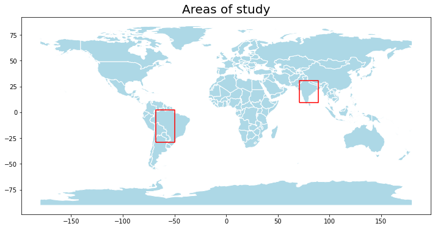

```python
#Using geopandas library
aoi = gpd.read_file('data/areas.geojson')
#The world layer is available in the custom datasets of geopandas
world = gpd.read_file(gpd.datasets.get_path('naturalearth_lowres'))

fig, ax1 = plt.subplots (figsize=(12, 8))
world.plot(color='lightblue',edgecolor='white',ax=ax1)
aoi.boundary.plot(ax=ax1, color="red")
ax1.set_title("Areas of study", fontsize=20)
plt.show()
```

In the research previous to the data analysis, I have founded that the AOI are the countries with higher amount of soybean crop.

### Explore the data

According to the publication *IFRI, 2019, "Global Spatially-Disaggregated Crop Production Statistics Data for 2010 Version 2.0"* the SPAM2010 (Spatial Production Allocation Model) dataset has the purpose to disaggregate the crop statistics of agriculture production (harvested area, production, yield) within the different farming systems.

The data includes 42 crops and its statistics. With this, it is possible to know the importance of the soybean among other crops.

The data has 5 variables:

- **Harvested area** --> measured in ha. It represents the area where the crop is harvested.
- Physical Area
- Yield
- Production
- Value of production

The data to be exploded will be the harvested area of soybean crop according to the technology used.

#### Farming systems

Soybean yield vary according to the farming system used. The next graph explains the different farming system types.

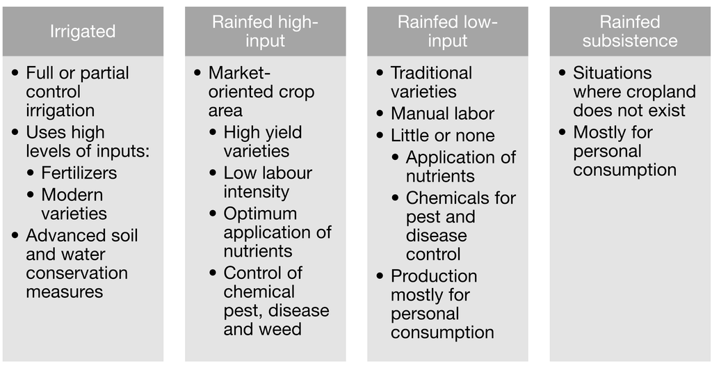

The difference between them is the water supply. The irrigated system need higher water than the rainfed ones.

Crop yields specifically change among farming system. In other words, depending on the technology, there is a greater impact on on soil nutrient loss, deforestation and water runoff.

The technologies are divided into different datasets. We will merge all in one filtering by AOI.

- _TI--> irrigated portion of crop
- _TH--> rainfed high inputs portion of crop
- _TL--> rainfed low inputs portion of crop
- _TS--> rainfed subsistence portion of crop

```python
df_TI = pd.read_csv('data/HarvestedArea_spam2010/spam2010V2r0_global_H_TI.csv', encoding='cp1252')
df_TL = pd.read_csv('data/HarvestedArea_spam2010/spam2010V2r0_global_H_TL.csv', encoding='cp1252')
df_TS = pd.read_csv('data/HarvestedArea_spam2010/spam2010V2r0_global_H_TS.csv', encoding='cp1252')
df_TH = pd.read_csv('data/HarvestedArea_spam2010/spam2010V2r0_global_H_TH.csv', encoding='cp1252')
```

To join the dataframes of the different harvested areas by farming system, we should concatenate and then apply a spatial filter to get only the values inside the AOI.

- Due to memory problems, the dataframes will be created and filter lonely and then merged for the purpose
- The null values of soybean will be out

```python
#Irrigated
df_TI.head()
```

|  | iso3 | prod_level | alloc_key | cell5m | x | y | rec_type | tech_type | unit | whea_i | ... | trof_i | temf_i | vege_i | rest_i | crea_date | year_data | source | name_cntr | name_adm1 | name_adm2 |
| --- | --- | --- | --- | --- | --- | --- | --- | --- | --- | --- | --- | --- | --- | --- | --- | --- | --- | --- | --- | --- | --- |
| 0 | CHN | CH08078 | 4383640 | 1891479 | 123.291667 | 53.541667 | H | I | ha | 0.0 | ... | 0.0 | 0.0 | 0.0 | 0.0 | 04/24/20 07:04:41 PM | avg(2009-2011) | F avg2 | China | Heilongjiang | Mohexian |
| 1 | CHN | CH08078 | 4393627 | 1895786 | 122.208333 | 53.458333 | H | I | ha | 0.0 | ... | 0.0 | 0.0 | 0.0 | 0.0 | 04/24/20 07:04:41 PM | avg(2009-2011) | F avg2 | China | Heilongjiang | Mohexian |
| 2 | CHN | CH08078 | 4393628 | 1895787 | 122.291667 | 53.458333 | H | I | ha | 0.0 | ... | 0.0 | 0.0 | 0.0 | 0.0 | 04/24/20 07:04:41 PM | avg(2009-2011) | F avg2 | China | Heilongjiang | Mohexian |
| 3 | CHN | CH08078 | 4393629 | 1895788 | 122.375000 | 53.458333 | H | I | ha | 7.5 | ... | 0.0 | 0.0 | 0.0 | 0.0 | 04/24/20 07:04:41 PM | avg(2009-2011) | F avg2 | China | Heilongjiang | Mohexian |
| 4 | CHN | CH08078 | 4393637 | 1895796 | 123.041667 | 53.458333 | H | I | ha | 1.5 | ... | 0.0 | 0.0 | 0.0 | 0.0 | 04/24/20 07:04:41 PM | avg(2009-2011) | F avg2 | China | Heilongjiang | Mohexian |

5 rows × 57 columns

```python
#We need the x,y, tech_type, unit, soyb_i,name_cntr,name_adm1_name_adm2
df_soyb_irrigated = df_TI[['x','y','tech_type','unit','soyb_i','name_cntr','name_adm1','name_adm2']]
df_TI.count()

#Change column name of 'soyb_i' to 'soyb'
df_soyb_irrigated.columns=['soybean' if x=='soyb_i'else x for x in df_soyb_irrigated.columns]

#In column tech_type, change the values to the correct syntax
df_soyb_irrigated.loc[df_soyb_irrigated["tech_type"] == "I","tech_type"]="Irrigated farming system"

#Get only columns without null vallues
df_soyb_irrigated = df_soyb_irrigated[df_soyb_irrigated['soybean']!=0]

df_soyb_irrigated.head()
```

|  | x | y | tech_type | unit | soybean | name_cntr | name_adm1 | name_adm2 |
| --- | --- | --- | --- | --- | --- | --- | --- | --- |
| 15 | 124.375000 | 53.208333 | Irrigated farming system | ha | 0.1 | China | Heilongjiang | Tahexian |
| 23 | 125.625000 | 53.041667 | Irrigated farming system | ha | 0.1 | China | Heilongjiang | Tahexian |
| 25 | 125.708333 | 52.958333 | Irrigated farming system | ha | 0.2 | China | Heilongjiang | Tahexian |
| 28 | 125.625000 | 52.875000 | Irrigated farming system | ha | 0.1 | China | Heilongjiang | Tahexian |
| 67 | 125.875000 | 52.375000 | Irrigated farming system | ha | 0.2 | China | Heilongjiang | Humaxian |

```python
#Rainfed-high
df_soyb_rainfedhigh = df_TH[['x','y','tech_type','unit','soyb_h','name_cntr','name_adm1','name_adm2']]
df_soyb_rainfedhigh.columns=['soybean' if x=='soyb_h'else x for x in df_soyb_rainfedhigh.columns]
df_soyb_rainfedhigh.loc[df_soyb_rainfedhigh["tech_type"] == "H","tech_type"]="Rainfed-high farming system"
df_soyb_rainfedhigh = df_soyb_rainfedhigh[df_soyb_rainfedhigh['soybean']!=0]

df_soyb_rainfedhigh.head()
```

|  | x | y | tech_type | unit | soybean | name_cntr | name_adm1 | name_adm2 |
| --- | --- | --- | --- | --- | --- | --- | --- | --- |
| 0 | 123.291667 | 53.541667 | Rainfed-high farming system | ha | 90.0 | China | Heilongjiang | Mohexian |
| 1 | 122.208333 | 53.458333 | Rainfed-high farming system | ha | 55.8 | China | Heilongjiang | Mohexian |
| 2 | 122.291667 | 53.458333 | Rainfed-high farming system | ha | 90.0 | China | Heilongjiang | Mohexian |
| 3 | 122.375000 | 53.458333 | Rainfed-high farming system | ha | 90.0 | China | Heilongjiang | Mohexian |
| 4 | 123.041667 | 53.458333 | Rainfed-high farming system | ha | 90.0 | China | Heilongjiang | Mohexian |

```python
#Rainfed-low
df_soyb_lowrainfed = df_TL[['x','y','tech_type','unit','soyb_l','name_cntr','name_adm1','name_adm2']]
df_soyb_lowrainfed.columns=['soybean' if x=='soyb_l'else x for x in df_soyb_lowrainfed.columns]
df_soyb_lowrainfed.loc[df_soyb_lowrainfed["tech_type"] == "L","tech_type"]="Rainfed-low farming system"
df_soyb_lowrainfed = df_soyb_lowrainfed[df_soyb_lowrainfed['soybean']!=0]

df_soyb_lowrainfed.head()
```

|  | x | y | tech_type | unit | soybean | name_cntr | name_adm1 | name_adm2 |
| --- | --- | --- | --- | --- | --- | --- | --- | --- |
| 58497 | 76.208333 | 32.875000 | Rainfed-low farming system | ha | 4.2 | India | Himachal Pradesh | Chamba |
| 58917 | 75.958333 | 32.791667 | Rainfed-low farming system | ha | 2.0 | India | Himachal Pradesh | Chamba |
| 58919 | 76.125000 | 32.791667 | Rainfed-low farming system | ha | 4.6 | India | Himachal Pradesh | Chamba |
| 58920 | 76.208333 | 32.791667 | Rainfed-low farming system | ha | 3.4 | India | Himachal Pradesh | Chamba |
| 59332 | 75.958333 | 32.708333 | Rainfed-low farming system | ha | 3.4 | India | Himachal Pradesh | Chamba |

```python
#Rainfed susbsistence
df_soyb_subsistence = df_TS[['x','y','tech_type','unit','soyb_s','name_cntr','name_adm1','name_adm2']]
df_soyb_subsistence.columns=['soybean' if x=='soyb_s'else x for x in df_soyb_subsistence.columns]
df_soyb_subsistence.loc[df_soyb_subsistence["tech_type"] == "S","tech_type"]="Subsistence farming system"
df_soyb_subsistence = df_soyb_subsistence[df_soyb_subsistence['soybean']!=0]

df_soyb_subsistence.head()
```

|  | x | y | tech_type | unit | soybean | name_cntr | name_adm1 | name_adm2 |
| --- | --- | --- | --- | --- | --- | --- | --- | --- |
| 1001 | 125.291667 | 50.125000 | Subsistence farming system | ha | 5.3 | China | Inner Mongolia | Elunchun |
| 1114 | 124.958333 | 50.041667 | Subsistence farming system | ha | 264.8 | China | Inner Mongolia | Elunchun |
| 1115 | 125.041667 | 50.041667 | Subsistence farming system | ha | 381.4 | China | Inner Mongolia | Elunchun |
| 1116 | 125.125000 | 50.041667 | Subsistence farming system | ha | 702.5 | China | Inner Mongolia | Elunchun |
| 1118 | 125.291667 | 50.041667 | Subsistence farming system | ha | 143.8 | China | Heilongjiang | Nenjiang |

Once the dataframes are ready, we have to spatially filter to the AOI. To do that, first it is necessary yo give the spatial extension to the dataframes, converting them into geodataframes

```python
#the coordinates are in the columns x and y
gdf_irrigated = gpd.GeoDataFrame(df_soyb_irrigated, geometry=gpd.points_from_xy(df_soyb_irrigated.x, df_soyb_irrigated.y))

#to ensure that have the WGS84 coordinate system, set the CRS for all geodataframes
gdf_irrigated.set_crs(epsg=4326, inplace=True)

gdf_irrigated.head()
```

|  | x | y | tech_type | unit | soybean | name_cntr | name_adm1 | name_adm2 | geometry |
| --- | --- | --- | --- | --- | --- | --- | --- | --- | --- |
| 15 | 124.375000 | 53.208333 | Irrigated farming system | ha | 0.1 | China | Heilongjiang | Tahexian | POINT (124.37500 53.20833) |
| 23 | 125.625000 | 53.041667 | Irrigated farming system | ha | 0.1 | China | Heilongjiang | Tahexian | POINT (125.62500 53.04167) |
| 25 | 125.708333 | 52.958333 | Irrigated farming system | ha | 0.2 | China | Heilongjiang | Tahexian | POINT (125.70833 52.95833) |
| 28 | 125.625000 | 52.875000 | Irrigated farming system | ha | 0.1 | China | Heilongjiang | Tahexian | POINT (125.62500 52.87500) |
| 67 | 125.875000 | 52.375000 | Irrigated farming system | ha | 0.2 | China | Heilongjiang | Humaxian | POINT (125.87500 52.37500) |

```python
gdf_rainfedhigh = gpd.GeoDataFrame(df_soyb_rainfedhigh, geometry=gpd.points_from_xy(df_soyb_rainfedhigh.x, df_soyb_rainfedhigh.y))
gdf_rainfedhigh.set_crs(epsg=4326, inplace=True)

gdf_rainfedhigh.head()
```

|  | x | y | tech_type | unit | soybean | name_cntr | name_adm1 | name_adm2 | geometry |
| --- | --- | --- | --- | --- | --- | --- | --- | --- | --- |
| 0 | 123.291667 | 53.541667 | Rainfed-high farming system | ha | 90.0 | China | Heilongjiang | Mohexian | POINT (123.29167 53.54167) |
| 1 | 122.208333 | 53.458333 | Rainfed-high farming system | ha | 55.8 | China | Heilongjiang | Mohexian | POINT (122.20833 53.45833) |
| 2 | 122.291667 | 53.458333 | Rainfed-high farming system | ha | 90.0 | China | Heilongjiang | Mohexian | POINT (122.29167 53.45833) |
| 3 | 122.375000 | 53.458333 | Rainfed-high farming system | ha | 90.0 | China | Heilongjiang | Mohexian | POINT (122.37500 53.45833) |
| 4 | 123.041667 | 53.458333 | Rainfed-high farming system | ha | 90.0 | China | Heilongjiang | Mohexian | POINT (123.04167 53.45833) |

```python
gdf_lowrainfed = gpd.GeoDataFrame(df_soyb_lowrainfed, geometry=gpd.points_from_xy(df_soyb_lowrainfed.x, df_soyb_lowrainfed.y))
gdf_lowrainfed.set_crs(epsg=4326, inplace=True)

gdf_lowrainfed.head()
```

|  | x | y | tech_type | unit | soybean | name_cntr | name_adm1 | name_adm2 | geometry |
| --- | --- | --- | --- | --- | --- | --- | --- | --- | --- |
| 58497 | 76.208333 | 32.875000 | Rainfed-low farming system | ha | 4.2 | India | Himachal Pradesh | Chamba | POINT (76.20833 32.87500) |
| 58917 | 75.958333 | 32.791667 | Rainfed-low farming system | ha | 2.0 | India | Himachal Pradesh | Chamba | POINT (75.95833 32.79167) |
| 58919 | 76.125000 | 32.791667 | Rainfed-low farming system | ha | 4.6 | India | Himachal Pradesh | Chamba | POINT (76.12500 32.79167) |
| 58920 | 76.208333 | 32.791667 | Rainfed-low farming system | ha | 3.4 | India | Himachal Pradesh | Chamba | POINT (76.20833 32.79167) |
| 59332 | 75.958333 | 32.708333 | Rainfed-low farming system | ha | 3.4 | India | Himachal Pradesh | Chamba | POINT (75.95833 32.70833) |

```python
gdf_subsistence = gpd.GeoDataFrame(df_soyb_subsistence, geometry=gpd.points_from_xy(df_soyb_subsistence.x, df_soyb_subsistence.y))
gdf_subsistence.set_crs(epsg=4326, inplace=True)
gdf_subsistence.head()
```

|  | x | y | tech_type | unit | soybean | name_cntr | name_adm1 | name_adm2 | geometry |
| --- | --- | --- | --- | --- | --- | --- | --- | --- | --- |
| 1001 | 125.291667 | 50.125000 | Subsistence farming system | ha | 5.3 | China | Inner Mongolia | Elunchun | POINT (125.29167 50.12500) |
| 1114 | 124.958333 | 50.041667 | Subsistence farming system | ha | 264.8 | China | Inner Mongolia | Elunchun | POINT (124.95833 50.04167) |
| 1115 | 125.041667 | 50.041667 | Subsistence farming system | ha | 381.4 | China | Inner Mongolia | Elunchun | POINT (125.04167 50.04167) |
| 1116 | 125.125000 | 50.041667 | Subsistence farming system | ha | 702.5 | China | Inner Mongolia | Elunchun | POINT (125.12500 50.04167) |
| 1118 | 125.291667 | 50.041667 | Subsistence farming system | ha | 143.8 | China | Heilongjiang | Nenjiang | POINT (125.29167 50.04167) |

Before getting all the data into one single geodataframe, we will apply the spatial filter by the bouding box defined by the AOI. AOI is divided into two zones, so the spatial filter will be done in two steps and then merge.

```python
#Filter the data by the bounding box of the AOI
aoi.bounds
```

|  | minx | miny | maxx | maxy |
| --- | --- | --- | --- | --- |
| 0 | 70.664062 | 9.449062 | 88.945312 | 30.448674 |
| 1 | -68.203125 | -28.921631 | -49.570312 | 2.460181 |

#### South Asia Region

```python
#Bounds of South Asia region for the systems
sa_irrigated = gdf_irrigated.cx[70.664062:88.945312, 9.449062:30.448674]
sa_rainfedhigh = gdf_rainfedhigh.cx[70.664062:88.945312, 9.449062:30.448674]
sa_rainfedlow = gdf_lowrainfed.cx[70.664062:88.945312, 9.449062:30.448674]
sa_subsistence = gdf_subsistence.cx[70.664062:88.945312, 9.449062:30.448674]
```

#### Latin America Region

```python
#Bounds of Latin America Region
la_irrigated = gdf_irrigated.cx[-68.203125:-49.570312, -28.921631:2.460181]
la_rainfedhigh = gdf_rainfedhigh.cx[-68.203125:-49.570312, -28.921631:2.460181]
la_rainfedlow = gdf_lowrainfed.cx[-68.203125:-49.570312, -28.921631:2.460181]
la_subsistence = gdf_subsistence.cx[-68.203125:-49.570312, -28.921631:2.460181]
```

```python
#Concatenate all the geodataframes
sa_tech = pd.concat([sa_irrigated,sa_rainfedhigh,sa_rainfedlow,sa_subsistence], ignore_index=True, sort=True)
la_tech = pd.concat([la_irrigated,la_rainfedhigh,la_rainfedlow,la_subsistence], ignore_index=True, sort=True)
```

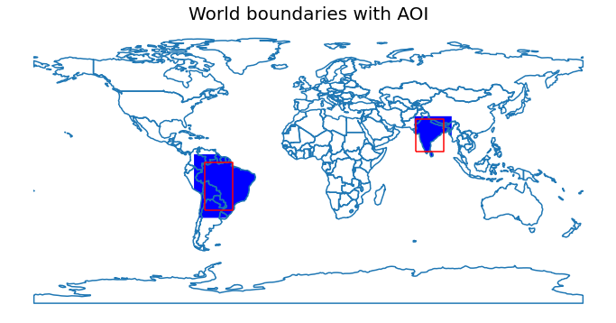

```python
#Clip world boundaries with bbox chosen. This area is a bit bigger than the AOI to improve vizualisation
#Get bbox for outer part of AOI in Latin America and Caribbean Region
bbox_la = (-75.058594,-34.016242,-32.871094,7.623887)
polygon_la = shapely.geometry.box(*bbox_la, ccw=True)

#Get bbox for outer part of AOI in South Asia Region
bbox_sa = (69.565430,5.484768,93.911133,32.583849)
polygon_sa = shapely.geometry.box(*bbox_sa, ccw=True)

#Create geodataframe for each region
sa = gpd.GeoDataFrame(crs='epsg:4326', geometry= [polygon_sa])
la = gpd.GeoDataFrame(crs='epsg:4326', geometry= [polygon_la])

#Clip the world gdf to show the outputs
world_clipped_sa = world.clip(sa)
world_clipped_la = world.clip(la)

fig, ax = plt.subplots(figsize=(12, 8))
world_clipped_sa.plot(ax=ax, color="blue")
world_clipped_la.plot(ax=ax, color="blue")
world.boundary.plot(ax=ax)
aoi.boundary.plot(ax=ax, color="red")
ax.set_title("World boundaries with AOI", fontsize=20)
ax.set_axis_off()
plt.show()
```

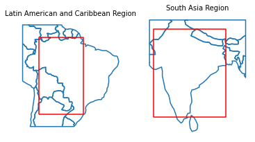

```python
#Prepare plot for AOI
fig, (ax1,ax2) = plt.subplots(1,2)
world_clipped_la.boundary.plot(ax=ax1)
aoi_la= gpd.GeoSeries(aoi.iloc[1])
aoi_la.boundary.plot(ax=ax1, color="red")
ax1.set_title("Latin American and Caribbean Region", fontsize=10)
ax1.set_axis_off()
# ax1.plot(world_clipped_la,aoi_la)

world_clipped_sa.boundary.plot(ax=ax2)
aoi_sa= gpd.GeoSeries(aoi.iloc[0])
aoi_sa.boundary.plot(ax=ax2, color="red")
ax2.set_title("South Asia Region", fontsize=10)
ax2.set_axis_off()


plt.show()
```

```python
#Check if all farming technologies are in the two regions
print('In Latin America and Caribbean Region, there are the following farming systems ' + str(la_tech['tech_type'].unique()))
print('In South Asia , there are the following farming systems ' + str(sa_tech['tech_type'].unique()))
```

```
In Latin America and Caribbean Region, there are the following farming systems ['Irrigated farming system' 'Rainfed-high farming system'
 'Rainfed-low farming system']
In South Asia , there are the following farming systems ['Irrigated farming system' 'Rainfed-high farming system'
 'Rainfed-low farming system' 'Subsistence farming system']
```

So, we know that in Latin America and Caribbean Region, there is only three farming systems

- Irrigated farming system
- Rainfed-high farming system
- Rainfed-low farming system

Now, we will map and then calculate the surface of each one and compare them

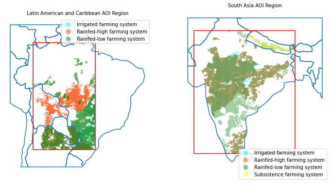

```python
color_dict_la = {'Irrigated farming system':'aqua','Rainfed-high farming system':'orangered', 'Rainfed-low farming system':'forestgreen'}
color_dict_sa = {'Irrigated farming system':'aqua','Rainfed-high farming system':'orangered', 'Rainfed-low farming system':'forestgreen', 'Subsistence farming system':'yellow'}

fig, (ax_la,ax_sa) = plt.subplots(1,2, figsize=(12,8))
world_clipped_la.boundary.plot(ax=ax_la)
aoi_la= gpd.GeoSeries(aoi.iloc[1])
aoi_la.boundary.plot(ax=ax_la, color="red")
ax_la.set_title("Latin American and Caribbean AOI Region", fontsize=10)
la_tech.plot(ax=ax_la, categorical=True,column="tech_type", alpha=0.5, legend=True, marker='x', markersize= 0.05, cmap=colors.ListedColormap(list(color_dict_la.values())))
ax_la.set_axis_off()


world_clipped_sa.boundary.plot(ax=ax_sa)
aoi_sa= gpd.GeoSeries(aoi.iloc[0])
aoi_sa.boundary.plot(ax=ax_sa, color="red")
ax_sa.set_title("South Asia AOI Region", fontsize=10)
sa_tech.plot(ax=ax_sa, categorical=True,column="tech_type", alpha=0.5, legend=True, marker='x', markersize= 0.05, cmap=colors.ListedColormap(list(color_dict_sa.values())))
ax_sa.set_axis_off()
```

Apparently, the technology with higher surface is rainfed-high farming system. Let's check with the tables

```python
#Subset to calculate areas
label= sa_tech.groupby(['tech_type'])

sa_tec = (sa_tech.groupby(['tech_type','name_cntr'])['soybean'].sum()).to_frame()
sa_tec.head()
```

| tech_type | name_cntr | soybean |
| --- | --- | --- |
| Irrigated farming system | Bangladesh | 4.1 |
|  | India | 62965.7 |
| Rainfed-high farming system | Bangladesh | 1.5 |
|  | India | 5364232.9 |
| Rainfed-low farming system | Bangladesh | 0.9 |

```python
#Get the statistics
sa_tec_statistics = sa_tec.groupby(['tech_type','name_cntr'])\
                            .agg(min_soybean_ha = ('soybean', 'min'), \
                                 mean_soybean_ha = ('soybean', 'mean'),
                                 max_soybean_ha = ('soybean', 'max')).round(2)
sa_tec_statistics
```

| tech_type | name_cntr | min_soybean_ha | mean_soybean_ha | max_soybean_ha |
| --- | --- | --- | --- | --- |
| Irrigated farming system | Bangladesh | 4.1 | 4.1 | 4.1 |
|  | India | 62965.7 | 62965.7 | 62965.7 |
| Rainfed-high farming system | Bangladesh | 1.5 | 1.5 | 1.5 |
|  | India | 5364232.9 | 5364232.9 | 5364232.9 |
| Rainfed-low farming system | Bangladesh | 0.9 | 0.9 | 0.9 |
|  | Bhutan | 57.3 | 57.3 | 57.3 |
|  | India | 4367785.6 | 4367785.6 | 4367785.6 |
|  | Nepal | 23021.2 | 23021.2 | 23021.2 |
| Subsistence farming system | Bangladesh | 3.9 | 3.9 | 3.9 |
|  | Bhutan | 2.9 | 2.9 | 2.9 |
|  | Nepal | 2557.0 | 2557.0 | 2557.0 |

```python
#Subset to calculate areas
la_tec = (la_tech.groupby(['tech_type','name_cntr'])['soybean'].sum()).to_frame()

#Create column to obtain total area
la_tec['total_area'] = la_tec['soybean'].sum()
la_tec.head()
```

| tech_type | name_cntr | soybean | total_area |
| --- | --- | --- | --- |
| Irrigated farming system | Argentina | 15324.5 | 23343209.1 |
|  | Bolivia | 17759.1 | 23343209.1 |
|  | Brazil | 22184.7 | 23343209.1 |
| Rainfed-high farming system | Argentina | 1103330.8 | 23343209.1 |
|  | Bolivia | 1037755.4 | 23343209.1 |

```python
la_tec_statistics = la_tec.groupby(['tech_type','name_cntr'])\
                            .agg(min_soybean_ha = ('soybean', 'min'), \
                                 mean_soybean_ha = ('soybean', 'mean'),
                                 max_soybean_ha = ('soybean', 'max')).round(2)
la_tec_statistics
```

| tech_type | name_cntr | min_soybean_ha | mean_soybean_ha | max_soybean_ha |
| --- | --- | --- | --- | --- |
| Irrigated farming system | Argentina | 15324.5 | 15324.5 | 15324.5 |
|  | Bolivia | 17759.1 | 17759.1 | 17759.1 |
|  | Brazil | 22184.7 | 22184.7 | 22184.7 |
| Rainfed-high farming system | Argentina | 1103330.8 | 1103330.8 | 1103330.8 |
|  | Bolivia | 1037755.4 | 1037755.4 | 1037755.4 |
|  | Brazil | 8923068.5 | 8923068.5 | 8923068.5 |
|  | Paraguay | 804651.7 | 804651.7 | 804651.7 |
| Rainfed-low farming system | Argentina | 1096883.4 | 1096883.4 | 1096883.4 |
|  | Brazil | 8444732.0 | 8444732.0 | 8444732.0 |
|  | Paraguay | 1877519.0 | 1877519.0 | 1877519.0 |

```python
# Create pie chart for South America
pie_sa_tec=sa_tech[['tech_type','soybean']]
pie_sa_tec= pie_sa_tec.groupby('tech_type')['soybean'].sum()
```

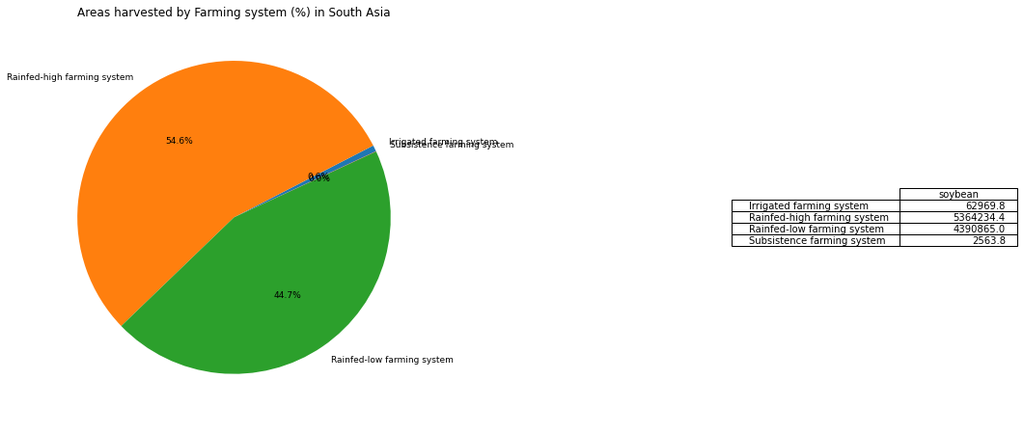

```python
plt.figure(figsize=(16,8))
# plot chart
ax1 = plt.subplot(121)
plt.axis('off')
pie_sa_tec.plot(kind='pie', ax=ax1, autopct='%1.1f%%', startangle=25,legend=False, fontsize=9)
ax1.set_title('Areas harvested by Farming system (%) in South Asia')

# plot table
ax2 = plt.subplot(122)
plt.axis('off')
tbl = table(ax2, pie_sa_tec, loc='right', colWidths=[0.3,0.3])

tbl.set_fontsize(10)
plt.show()
```

```python
# Create pie chart for Latin America
pie_la_tec=la_tech[['tech_type','soybean']]
pie_la_tec= pie_la_tec.groupby('tech_type')['soybean'].sum()
```

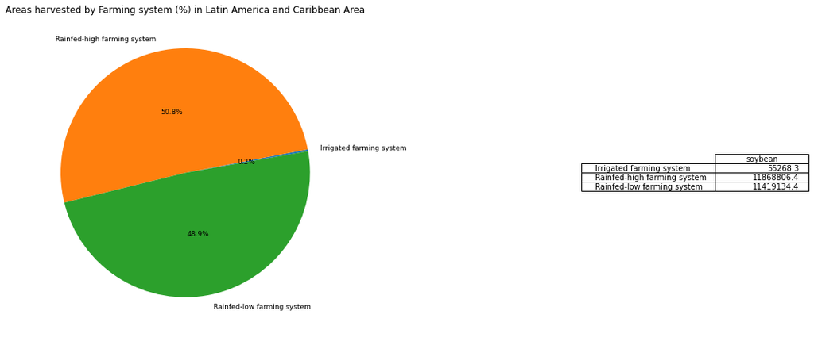

```python
plt.figure(figsize=(16,8))
# plot chart
ax1 = plt.subplot(121)
plt.axis('off')
pie_la_tec.plot(kind='pie', ax=ax1, autopct='%1.1f%%',pctdistance=0.5, startangle=10,legend=False, fontsize=9)
ax1.set_title('Areas harvested by Farming system (%) in Latin America and Caribbean Area')

# plot table
ax2 = plt.subplot(122)
plt.axis('off')
tbl = table(ax2, pie_la_tec, loc='right', colWidths=[0.3,0.3])

tbl.set_fontsize(10)
plt.show()
```

### Final conclusions

- Latin America and Caribbean area represent more harvested surface.
- The farming system most used is rainfed the areas are the most productive ones of the world, so data is consistent
- for the presentation of the test, more conclusions to be explained!

#### For future versions

There are some things that in future versions I would like to develop:

- explore GlobalForest dataset into jupyter notebook (I was not able)
- explore land rights regarding the small-scale farmers and how soybean crops affect
- evaluate CO2 loss in the last years (if dataset available)
- set traceability to soy crops
- evaluate among other layers (biodiversity, soil health, etc)